# HDPS Package Tutorial

Min Fan, Edmund Chueng

2025-10-26

# Introduction

The `hdps` package implements the High-Dimensional Propensity Score (HDPS) algorithm for automated covariate selection in observational studies.

## Key Features

- **Modular workflow**: 3-step process (identify → assess → prioritize)
- **Performance**: Parallel processing for large datasets
- **Visualizations**: Interactive plots for bias analysis
- **Data flexibility**: Multiple input formats

# Installation

```r
# Install from GitHub
devtools::install_github("Cainefm/hdps")

# Or install from local .tar.gz file
install.packages("hdps_0.9.0.tar.gz", repos = NULL, type = "source")
```

# Basic Usage

## Load the Package

```r
library(hdps)
library(data.table)
library(ggplot2)
```

## Example Dataset

Let’s create a sample dataset to demonstrate the package functionality:

```r
# Create sample diagnosis data
set.seed(123)
n_patients <- 100
n_codes <- 50

# Generate patient IDs and diagnosis codes
dx_data <- data.table(
  pid = rep(1:n_patients, each = n_codes),
  code = rep(paste0("ICD", sprintf("%03d", 1:n_codes)), n_patients),
  type = "dx"
)

# Add some variation - not all patients have all codes
dx_data <- dx_data[sample(nrow(dx_data), nrow(dx_data) * 0.3), ]

# Create master table with exposure and outcome
master_data <- data.table(
  pid = 1:n_patients,
  exposure = rbinom(n_patients, 1, 0.5),
  outcome = rbinom(n_patients, 1, 0.3)
)

# Merge with exposure/outcome data
dx_data <- merge(dx_data, master_data, by = "pid", all.x = TRUE)

head(dx_data)
```

```
## Key: <pid>
##      pid   code   type exposure outcome
##    <int> <char> <char>    <int>   <int>
## 1:     1 ICD041     dx        1       0
## 2:     1 ICD031     dx        1       0
## 3:     1 ICD049     dx        1       0
## 4:     1 ICD044     dx        1       0
## 5:     1 ICD045     dx        1       0
## 6:     1 ICD001     dx        1       0
```

## Complete HDPS Workflow

```r
# Complete HDPS workflow in one function (using single core to avoid vignette issues)
results <- hdps(
  data = dx_data,
  id_col = "pid",
  code_col = "code",
  exposure_col = "exposure",
  outcome_col = "outcome",
  master_data = master_data,
  n_candidates = 20,
  min_patients = 5,
  n_cores = 1  # Use single core for vignette
)

# View results
head(results$prioritization[order(absLogBias, decreasing = TRUE)])
```

```
##                   code    e1    e0    d1    d0    c1    c0  e1c1  e0c1  e1c0
##                 <char> <int> <int> <int> <int> <int> <int> <int> <int> <int>
## 1: cov_cov_ICD036_spor    49    51    27    73    13    87     7     6    42
## 2: cov_cov_ICD003_freq    49    51    27    73    12    88     4     8    45
## 3: cov_cov_ICD004_spor    49    51    27    73    12    88     9     3    40
## 4: cov_cov_ICD037_spor    49    51    27    73    12    88     7     5    42
## 5: cov_cov_ICD001_freq    49    51    27    73    11    89     6     5    43
## 6: cov_cov_ICD022_spor    49    51    27    73    11    89     4     7    45
##     e0c0  d1c1  d0c1  d1c0  d0c0   pc1   pc0      rrCE       rrCD     bias
##    <int> <num> <num> <num> <num> <num> <num>     <num>      <num>    <num>
## 1:    45   0.1  13.1  27.1  60.1  0.13  0.87 1.1153846 0.02469486 5.764353
## 2:    43   1.0  11.0  26.0  62.0  0.12  0.88 0.6518519 0.28205128 2.481894
## 3:    48   1.0  11.0  26.0  62.0  0.12  0.88 1.6500000 0.28205128 2.481894
## 4:    46   1.0  11.0  26.0  62.0  0.12  0.88 1.2222222 0.28205128 2.481894
## 5:    46   1.0  10.0  26.0  63.0  0.11  0.89 1.1289641 0.31118881 2.388452
## 6:    44   1.0  10.0  26.0  63.0  0.11  0.89 0.7191919 0.31118881 2.388452
##    absLogBias ce_strength cd_strength
##         <num>       <num>       <num>
## 1:  1.7516929   0.1153846   0.9753051
## 2:  0.9090220   0.3481481   0.7179487
## 3:  0.9090220   0.6500000   0.7179487
## 4:  0.9090220   0.2222222   0.7179487
## 5:  0.8706455   0.1289641   0.6888112
## 6:  0.8706455   0.2808081   0.6888112
```

# Advanced Features

## Multi-Domain Analysis

```r
# Create multi-domain data
dx_data <- data.table(pid = 1:100, code = paste0("DX", 1:100), type = "dx")
px_data <- data.table(pid = 1:100, code = paste0("PX", 1:100), type = "px")
rx_data <- data.table(pid = 1:100, code = paste0("RX", 1:100), type = "rx")

# Multi-domain analysis
multi_domain_results <- hdps_multi_domain(
  data_list = list(dx = dx_data, px = px_data, rx = rx_data),
  id_col = "pid",
  code_col = "code",
  exposure_col = "exposure",
  outcome_col = "outcome"
)
```

## Complete Workflow with hdps

```r
# Complete workflow in one function
results <- hdps(
  data = dx_data,
  id_col = "pid",
  code_col = "code",
  exposure_col = "exposure",
  outcome_col = "outcome",
  master_data = master_data,
  n_candidates = 20,
  min_patients = 5,
  n_cores = 1
)

# View results
str(results)
```

```
## List of 3
##  $ candidates    :List of 3
##   ..$ candidates :Classes 'data.table' and 'data.frame': 20 obs. of  4 variables:
##   .. ..$ code                : chr [1:20] "ICD049" "ICD006" "ICD036" "ICD015" ...
##   .. ..$ n_patients          : int [1:20] 43 41 38 37 37 37 37 36 36 35 ...
##   .. ..$ prevalence          : num [1:20] 43 41 38 37 37 37 37 36 36 35 ...
##   .. ..$ prevalence_truncated: num [1:20] 43 41 38 37 37 37 37 36 36 35 ...
##   .. ..- attr(*, ".internal.selfref")=<externalptr>
##   ..$ data       :Classes 'data.table' and 'data.frame': 695 obs. of  2 variables:
##   .. ..$ pid : chr [1:695] "1" "1" "1" "1" ...
##   .. ..$ code: chr [1:695] "cov_ICD041" "cov_ICD031" "cov_ICD049" "cov_ICD001" ...
##   .. ..- attr(*, ".internal.selfref")=<externalptr>
##   ..$ patient_ids: int [1:100] 1 2 3 4 5 6 7 8 9 10 ...
##  $ recurrence    :Classes 'data.table' and 'data.frame': 100 obs. of  61 variables:
##   ..$ pid                : chr [1:100] "1" "10" "100" "11" ...
##   ..$ cov_cov_ICD001_freq: num [1:100] 1 0 0 0 0 0 1 0 0 0 ...
##   ..$ cov_cov_ICD001_once: num [1:100] 0 0 0 0 0 0 0 0 0 0 ...
##   ..$ cov_cov_ICD001_spor: num [1:100] 0 0 0 0 0 1 0 0 0 0 ...
##   ..$ cov_cov_ICD003_freq: num [1:100] 0 0 0 0 1 0 0 0 0 0 ...
##   ..$ cov_cov_ICD003_once: num [1:100] 0 0 1 0 0 0 0 1 0 0 ...
##   ..$ cov_cov_ICD003_spor: num [1:100] 0 0 0 1 0 0 0 0 0 1 ...
##   ..$ cov_cov_ICD004_freq: num [1:100] 0 0 0 0 0 0 0 0 0 1 ...
##   ..$ cov_cov_ICD004_once: num [1:100] 0 0 0 1 0 0 0 0 0 0 ...
##   ..$ cov_cov_ICD004_spor: num [1:100] 0 0 0 0 0 0 0 0 1 0 ...
##   ..$ cov_cov_ICD005_freq: num [1:100] 0 0 0 0 1 0 0 0 0 1 ...
##   ..$ cov_cov_ICD005_once: num [1:100] 0 0 0 0 0 1 0 0 0 0 ...
##   ..$ cov_cov_ICD005_spor: num [1:100] 0 0 1 0 0 0 0 0 1 0 ...
##   ..$ cov_cov_ICD006_freq: num [1:100] 0 0 0 0 0 1 0 0 1 0 ...
##   ..$ cov_cov_ICD006_once: num [1:100] 0 0 0 0 0 0 1 0 0 0 ...
##   ..$ cov_cov_ICD006_spor: num [1:100] 0 0 0 1 0 0 0 1 0 0 ...
##   ..$ cov_cov_ICD008_freq: num [1:100] 0 0 0 0 0 0 0 0 1 0 ...
##   ..$ cov_cov_ICD008_once: num [1:100] 0 0 0 0 0 0 0 0 0 0 ...
##   ..$ cov_cov_ICD008_spor: num [1:100] 0 1 0 0 0 0 0 0 0 0 ...
##   ..$ cov_cov_ICD009_freq: num [1:100] 0 1 0 0 0 0 0 0 0 0 ...
##   ..$ cov_cov_ICD009_once: num [1:100] 0 0 0 0 0 0 1 0 0 0 ...
##   ..$ cov_cov_ICD009_spor: num [1:100] 0 0 0 0 0 0 0 0 0 0 ...
##   ..$ cov_cov_ICD011_freq: num [1:100] 0 0 0 0 0 0 0 0 0 0 ...
##   ..$ cov_cov_ICD011_once: num [1:100] 1 0 1 0 0 0 0 1 0 0 ...
##   ..$ cov_cov_ICD011_spor: num [1:100] 0 0 0 0 0 0 0 0 0 0 ...
##   ..$ cov_cov_ICD015_freq: num [1:100] 0 0 0 0 0 1 0 0 0 0 ...
```

[output cut: 46 more lines]

```
##   ..$ e1c0       : int [1:60] 43 41 45 45 46 42 41 42 40 45 ...
##   ..$ e0c0       : int [1:60] 46 49 45 43 42 47 46 46 48 43 ...
##   ..$ d1c1       : num [1:60] 1 4 3 1 2 2 3 3 1 2 ...
##   ..$ d0c1       : num [1:60] 10 6 7 11 10 9 10 9 11 10 ...
##   ..$ d1c0       : num [1:60] 26 23 24 26 25 25 24 24 26 25 ...
##   ..$ d0c0       : num [1:60] 63 67 66 62 63 64 63 64 62 63 ...
##   ..$ pc1        : num [1:60] 0.11 0.1 0.1 0.12 0.12 0.11 0.13 0.12 0.12 0.12 ...
##   ..$ pc0        : num [1:60] 0.89 0.9 0.9 0.88 0.88 0.89 0.87 0.88 0.88 0.88 ...
##   ..$ rrCE       : num [1:60] 1.129 1.756 0.8 0.652 0.478 ...
##   ..$ rrCD       : num [1:60] 0.311 1.565 1.125 0.282 0.587 ...
##   ..$ bias       : num [1:60] 2.39 0.7 0.91 2.48 1.49 ...
##   ..$ absLogBias : num [1:60] 0.8706 0.3563 0.0942 0.909 0.4013 ...
##   ..$ ce_strength: num [1:60] 0.129 0.756 0.2 0.348 0.522 ...
##   ..$ cd_strength: num [1:60] 0.689 0.565 0.125 0.718 0.413 ...
##   ..- attr(*, ".internal.selfref")=<externalptr>
```

# Visualization

## Bias Distribution Plot

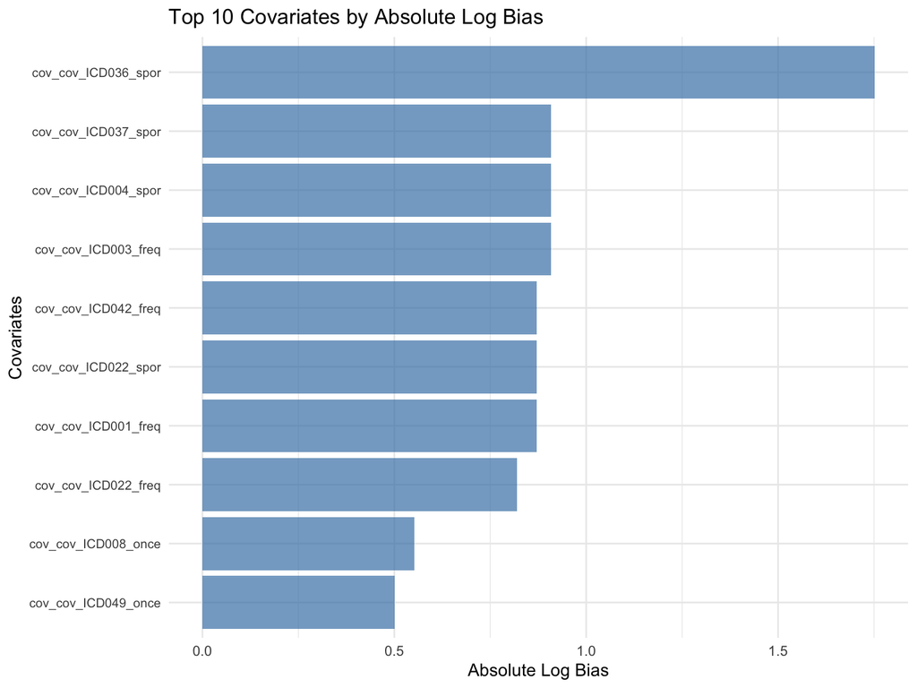

```r
# Plot bias distribution
p1 <- plot_bias_distribution(results$prioritization, top_n = 10)
print(p1)
```

## Covariate Strength Relationships

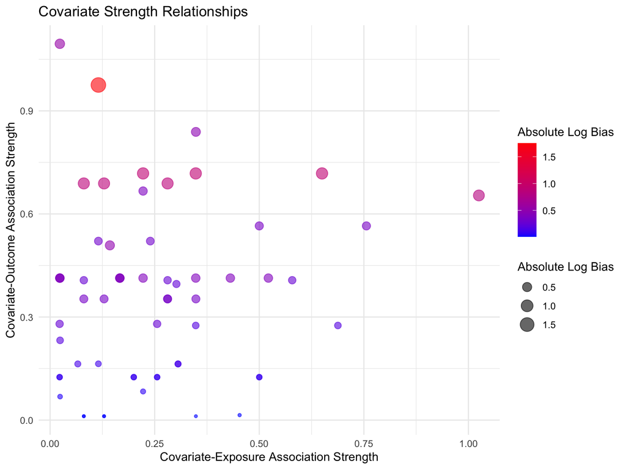

```r
# Plot covariate strength relationships
p2 <- plot_covariate_strength(results$prioritization)
print(p2)
```

## Bias vs Prevalence

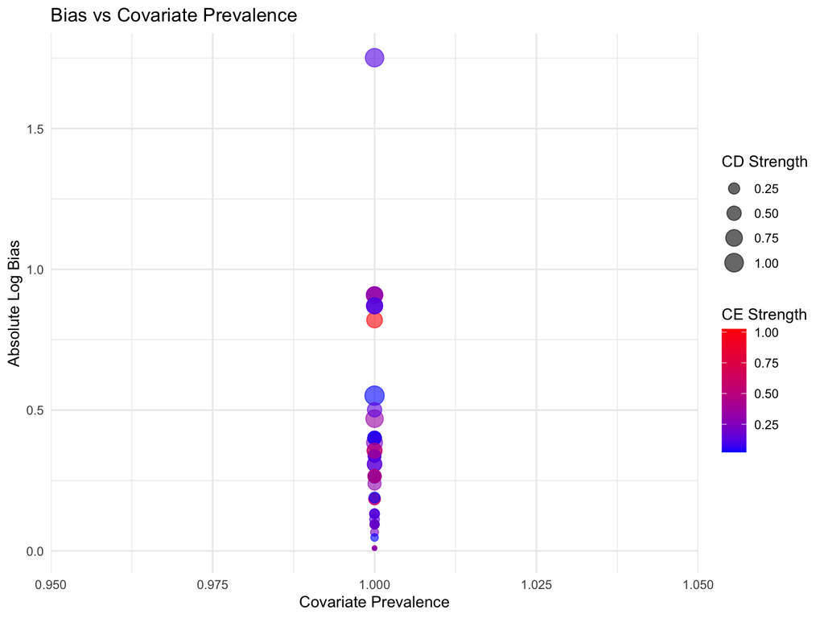

```r
# Plot bias vs prevalence
p3 <- plot_bias_vs_prevalence(results$prioritization)
print(p3)
```

## Interactive Plots

```r
# Note: For interactive analysis, use the hdps_interactive() function
# which provides a Shiny interface for covariate selection

# Example of interactive analysis:
# hdps_interactive()
```

# Flexible Data Input

## Different Input Formats

```r
# Long format (default)
data_long <- hdps_input(dx_data, format = "long")

# Wide format
wide_data <- dcast(dx_data, pid ~ code, value.var = "code", fun.aggregate = length)
data_wide <- hdps_input(wide_data, format = "wide", value_col = "count")

# Matrix format (example)
# matrix_data <- matrix(rbinom(100, 1, 0.5), nrow = 10, ncol = 10)
# rownames(matrix_data) <- paste0("P", 1:10)
# colnames(matrix_data) <- paste0("VAR", 1:10)
# data_matrix <- hdps_input(matrix_data, format = "matrix")
```

# Performance Tips

## Large Datasets

For large datasets, consider:

1. **Limit candidates**: Use smaller `n` values in `identify_candidates()`
2. **Filter data**: Remove rare codes before analysis
3. **Use data.table**: Ensure your data is in `data.table` format

## Memory Management

```r
# Monitor memory usage
library(pryr)
mem_used()

# Use gc() to free memory
gc()
```

# Best Practices

## Data Preparation

1. **Clean your data**: Remove missing values and invalid codes
2. **Standardize formats**: Ensure consistent column names and data types
3. **Validate inputs**: Check that required columns exist

## Parameter Selection

1. **n_candidates**: Start with 200-500, adjust based on your data size
2. **min_patients**: Use 10-50 depending on your sample size

## Quality Control

```r
# Check data quality
cat("Number of patients:", length(unique(dx_data$pid)), "\n")
```

```
## Number of patients: 100
```

```r
cat("Number of codes:", length(unique(dx_data$code)), "\n")
```

```
## Number of codes: 50
```

```r
cat("Missing values:", sum(is.na(dx_data)), "\n")
```

```
## Missing values: 0
```

```r
# Check exposure/outcome distribution
table(master_data$exposure)
```

```
##
##  0  1
## 51 49
```

```r
table(master_data$outcome)
```

```
##
##  0  1
## 73 27
```

# Troubleshooting

## Common Issues

1. **Memory errors**: Reduce `n_candidates` or filter data
2. **Slow performance**: Use data.table for better performance
3. **Missing data**: Check for NA values in your dataset
4. **Column name errors**: Ensure column names match exactly

## Debugging

```r
# Check intermediate results
candidates <- identify_candidates(dx_data, "pid", "code", "dx", n = 10)
cat("Number of candidates:", nrow(candidates$candidates), "\n")
```

```
## Number of candidates: 10
```

```r
# Check recurrence data
recurrence <- assess_recurrence(candidates$data, "pid", "code", "dx")
cat("Number of recurrence variables:", ncol(recurrence) - 1, "\n")
```

```
## Number of recurrence variables: 30
```

# Conclusion

The `hdps` package provides a comprehensive solution for high-dimensional propensity score analysis. Key features include:

- **Modular workflow** for flexible analysis
- **Domain-specific handling** for different data types
- **Parallel processing** for large datasets
- **Enhanced visualizations** for result interpretation
- **Flexible data input** for various formats

For more information, see the package documentation and examples.